# Run CoPro on brain MERFISH data

2024-10-08

# Content

This Vignette contains an example to run CoPro on a brain MERFISH data. The data is from Zhang et al. *Nature* 2023 (see reference 1). Here, we focus on detecting the co-progression between D1 and D2 neurons, as reported in the original publication. Here, we aim to show the unsupervised detection of continuous and coordinated cell progressions and how that is related to the tissue structure.

# load packages

```r
library("CoPro")
library_paths <- c(
  "fields", "ggplot2", "tictoc", "irlba",
  "Matrix", "ggsci", "ape"
)
# Load required libraries
lapply(library_paths, library, character.only = TRUE)
```

# set some parameters

We can change the number of PCs. For this dataset, this parameter does not affect the results much

```r
n_pca <- 40 ## number of top PCs to retain
cell_types <- c("061 STR D1 Gaba", "062 STR D2 Gaba")
n_cell_types <- length(cell_types)

horizontal_dist_scale <- 1
vertical_dist_scale <- 1
```

# Load data

Here we load the normalized gene matrix as well as the meta data. The cell type label as well as cell location information are in the meta data.

```r
ra <- readRDS("/Users/zhenmiao/Dropbox/Zhuang-ABCA-1.054_1/Zhuang_ABCA_1.054_subset_data.rds")
meta <- readRDS("/Users/zhenmiao/Dropbox/Zhuang-ABCA-1.054_1/Zhuang_ABCA_1.054_subset_metadata.rds")
```

## subset data

```r
subset_cells <- meta$subclass %in% cell_types

ra <- ra[subset_cells, ]
meta <- meta[subset_cells, ]
rownames(meta) <- meta$cell_label
## make sure coordinates are numeric
meta$x <- as.numeric(meta$x)
meta$y <- as.numeric(meta$y)
```

## show the in situ plot

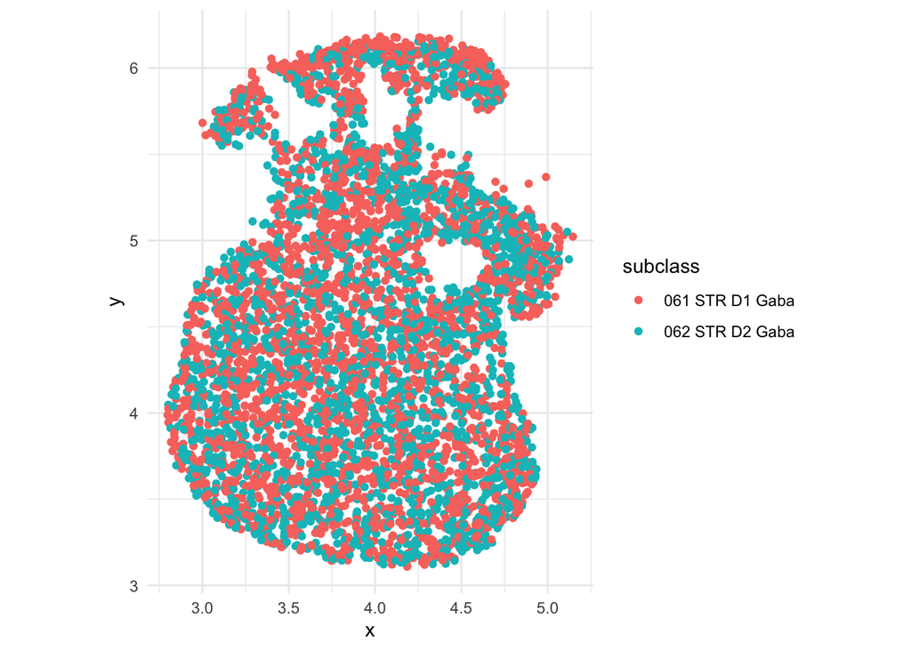

```r
ggplot(data = meta) +
  geom_point(aes(x = x, y = y, color = subclass)) +
  theme_minimal() +
  coord_fixed(ratio = 1)
```

# load data into object

```r
location_data <- meta[, c("x", "y")]
cell_type_data <- meta[, "subclass"]
br <- newCoPro(
  normalizedData = ra,
  locationData = location_data,
  metaData = meta,
  cellTypes = cell_type_data
)
br <- subsetData(br, cellTypesOfInterest = cell_types)
```

# compute distances

```r
br <- computePCA(br, nPCA = n_pca, center = TRUE, scale. = TRUE)
# sigma_square_choice <- c(0.001, 0.002, 0.005, 0.01, 0.02, 0.05, 0.1, 0.2)
sigma_value_choice <- c(0.1, 0.14, 0.2)
## By default, we normalize the distance
br <- computeDistance(br, distType = "Euclidean2D", normalizeDistance = FALSE)
```

```
## quantile of the distances between 061 STR D1 Gaba and 062 STR D2 Gaba is:
##         0%        25%        50%        75%       100%
## 0.01406832 0.77980408 1.21734420 1.70564639 3.10426158
```

```r
br <- computeKernelMatrix(br, sigmaValues = sigma_value_choice)
```

```
## normalizeKernel is set to TRUE. Kernel matrix will be normalized so that median row sums of kernel will be 1
## Current Sigma value is 0.1
## Quantiles of N_neighbors for cell type 061 STR D1 Gaba
## 32 133 176 196 256
## Quantiles of N_neighbors for cell type 062 STR D2 Gaba
## 72 162 196 231 274
## quantile of row sums of kernel matrix
## 0.3810386 18.34418 22.19348 25.32457 43.042
## Current Sigma value is 0.14
## Quantiles of N_neighbors for cell type 061 STR D1 Gaba
## 59 214 290 333 404
## Quantiles of N_neighbors for cell type 062 STR D2 Gaba
## 88 256 320 388 460
## quantile of row sums of kernel matrix
## 3.726739 34.9958 43.21776 48.41044 70.17906
## Current Sigma value is 0.2
## Quantiles of N_neighbors for cell type 061 STR D1 Gaba
## 101 344 471 573.25 695
## Quantiles of N_neighbors for cell type 062 STR D2 Gaba
## 162 413 538 651 776
## quantile of row sums of kernel matrix
## 20.12851 66.90792 89.32941 98.35571 122.2118
```

# run skrCCA and obtain correlations

```r
br <- runSkrCCA(br, scalePCs = TRUE, maxIter = 500)
```

```
## [1] "convergence reached at 32 iterations"
## [1] "convergence reached at 0 iterations"
## [1] "convergence reached at 25 iterations"
## [1] "convergence reached at 0 iterations"
## [1] "convergence reached at 19 iterations"
## [1] "convergence reached at 0 iterations"
```

```r
br <- computeNormalizedCorrelation(br)
```

```
## Calculating spectral norms,  depending on the data size, this may take a while.
## Finished calculating spectral norms
```

# compute gene and cell scores

```r
br <- computeGeneAndCellScores(br)
```

# Look across different sigma values

Here, we hope to pick the sigma value with the highest normalized correlation value. We visualize the trend using ggplot2

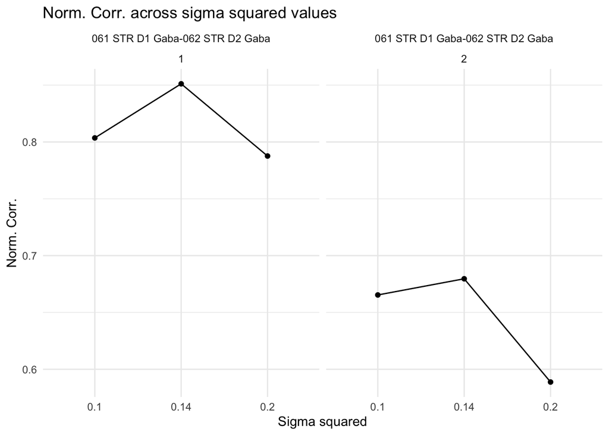

```r
ncorr <- getNormCorr(br)

ggplot(data = ncorr, aes(
  x = sigmaValues,
  y = normalizedCorrelation, group = 1
)) +
  geom_point() +
  geom_line() +
  facet_wrap(vars(ct12,CC_index)) +
  xlab("Sigma squared") +
  ylab("Norm. Corr.") +
  ggtitle(label = "Norm. Corr. across sigma squared values") +
  theme_minimal()
```

# Cell scores correlation

We can visualize the cell scores with respect to one another by plotting X<sub>A</sub>K<sub>AB</sub> against X<sub>B</sub>, where X<sub>A</sub> represents the cell scores of each cell in cell type A, and X<sub>B</sub> represents the cell scores of each cell in cell type B, and K<sub>AB</sub> represents the Kernel matrix between cell type A and B.

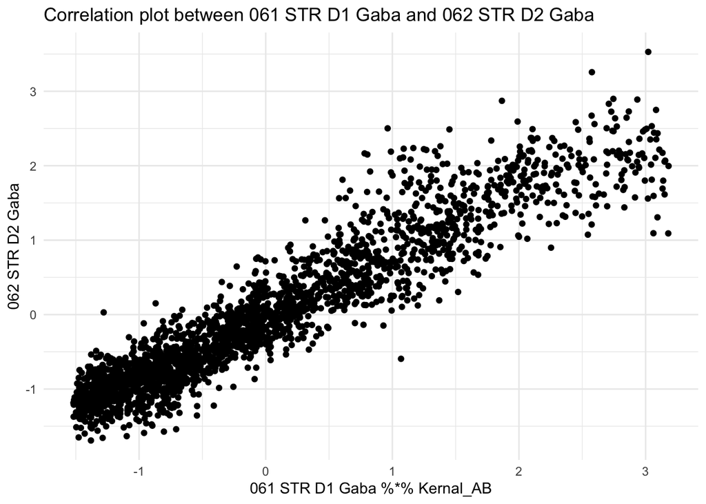

```r
cell_A <- "061 STR D1 Gaba"
cell_B <- "062 STR D2 Gaba"

df_crtt <- getCorrTwoTypes(br,
  sigmaValueChoice = 0.14,
  cellTypeA = cell_A,
  cellTypeB = cell_B
)

ggplot(df_crtt) +
  geom_point(aes(x = AK, y = B)) +
  ggtitle(paste("Correlation plot between", cell_A, "and", cell_B)) +
  xlab(paste(cell_A, "%*% Kernal_AB")) +
  ylab(cell_B) +
  theme_minimal()
```

# Cell scores in situ

We can retrive the `data.frame` that contains the cell scores using the following function:

```r
br_cs <- getCellScoresInSitu(br,
  sigmaValueChoice = 0.14,
  scoreColorType = "binary"
)
```

We can visualize the cell scores in situ using ggplot.

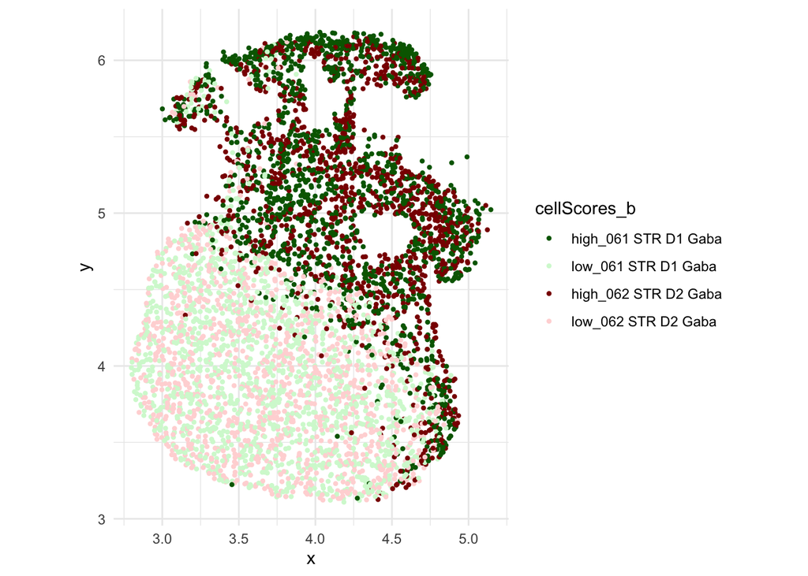

```r
ggplot(data = br_cs) +
  geom_point(aes(
    x = x,
    y = y,
    color = cellScores_b
  ), size = 0.8) +
  scale_color_discrete(
    type =
      c("darkgreen", "#d4f8d4", "darkred", "#ffd8d8")
  ) +
  coord_fixed() +
  theme_minimal()
```

We can also visualize the continuous scores

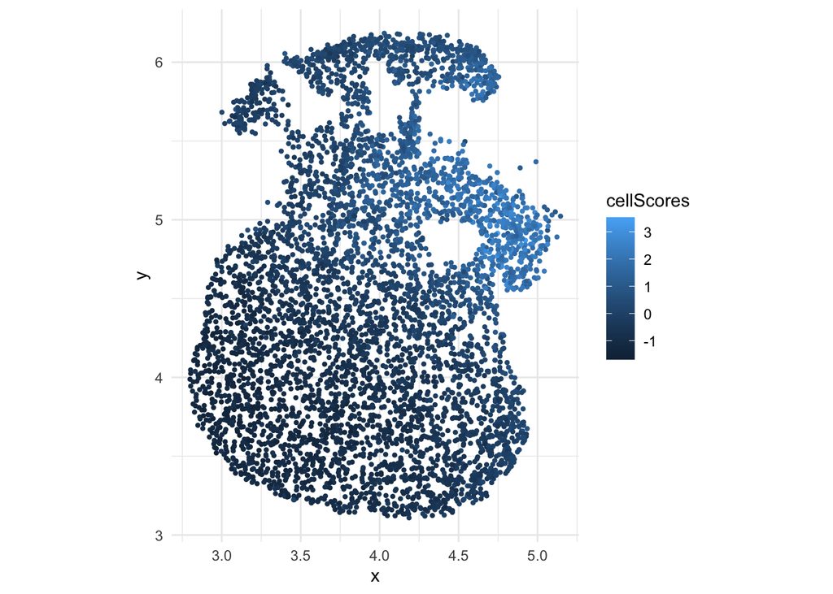

```r
ggplot(data = br_cs) +
  geom_point(aes(
    x = x,
    y = y,
    color = cellScores
  ), size = 0.8) +
  coord_fixed() +
  theme_minimal()
```

# Permutation to establish null

```r
br <- runSkrCCAPermu(br, nPermu = 5L, permu_method = "bin",
                     num_bins_x = 10, num_bins_y = 10)
```

```
## Cell permutation finished
## [1] "convergence reached at 11 iterations"
## [1] "convergence reached at 0 iterations"
## [1] "convergence reached at 16 iterations"
## [1] "convergence reached at 0 iterations"
## [1] "convergence reached at 25 iterations"
## [1] "convergence reached at 0 iterations"
## [1] "convergence reached at 37 iterations"
## [1] "convergence reached at 0 iterations"
## [1] "convergence reached at 16 iterations"
## [1] "convergence reached at 0 iterations"
```

```r
br <- computeNormalizedCorrelationPermu(br, tol = 1e-3)
```

```
## Calculating spectral norms,  depending on the data size, this may take a while.
## Finished calculating spectral norms
```

```r
nc_permu <- br@normalizedCorrelationPermu
# names(nc_permu) <- NULL
nc_permu <- do.call(rbind, nc_permu)
print(nc_permu)
```

```
##           sigmaValues       cellType1       cellType2 CC_index
## permu_1.1        0.14 061 STR D1 Gaba 062 STR D2 Gaba        1
## permu_1.2        0.14 061 STR D1 Gaba 062 STR D2 Gaba        2
## permu_2.1        0.14 061 STR D1 Gaba 062 STR D2 Gaba        1
## permu_2.2        0.14 061 STR D1 Gaba 062 STR D2 Gaba        2
## permu_3.1        0.14 061 STR D1 Gaba 062 STR D2 Gaba        1
## permu_3.2        0.14 061 STR D1 Gaba 062 STR D2 Gaba        2
## permu_4.1        0.14 061 STR D1 Gaba 062 STR D2 Gaba        1
## permu_4.2        0.14 061 STR D1 Gaba 062 STR D2 Gaba        2
## permu_5.1        0.14 061 STR D1 Gaba 062 STR D2 Gaba        1
## permu_5.2        0.14 061 STR D1 Gaba 062 STR D2 Gaba        2
##           normalizedCorrelation
## permu_1.1             0.4093333
## permu_1.2             0.2142201
## permu_2.1             0.3111483
## permu_2.2             0.2424558
## permu_3.1             0.2404399
## permu_3.2             0.2619129
## permu_4.1             0.2541483
## permu_4.2             0.3390264
## permu_5.1             0.4190558
## permu_5.2             0.2525904
```

# References:

The MERFISH data were downloaded from the following manuscript:

Zhang, M., Pan, X., Jung, W. *et al.* Molecularly defined and spatially resolved cell atlas of the whole mouse brain. *Nature* 624, 343–354 (2023). https://doi.org/10.1038/s41586-023-06808-9